# Practical Machine Learning Project

Rodrigo Falcão

2023-03-30

## Background

Using devices such as Jawbone Up, Nike FuelBand, and Fitbit it is now possible to collect a large amount of data about personal activity relatively inexpensively. These type of devices are part of the quantified self movement – a group of enthusiasts who take measurements about themselves regularly to improve their health, to find patterns in their behavior, or because they are tech geeks. One thing that people regularly do is quantify how much of a particular activity they do, but they rarely quantify how well they do it. In this project, your goal will be to use data from accelerometers on the belt, forearm, arm, and dumbell of 6 participants. They were asked to perform barbell lifts correctly and incorrectly in 5 different ways. More information is available from the website here: http://groupware.les.inf.puc-rio.br/har (see the section on the Weight Lifting Exercise Dataset).

## Loading Packages and Spliting Data

```r
library(caret)
library(rattle)

set.seed(666)
training_all <- read.csv("./data/pml-training.csv")
testing <- read.csv("./data/pml-testing.csv")

#Splitting Training Data in two parts: validation and training data sets
in_train <- createDataPartition(y=training_all$classe, p=0.7, list=F)
training <- training_all[in_train,]
validation <- training_all[-in_train,]

training <- training[, -c(1:7)]
validation <- validation[, -c(1:7)]
```

## Cleaning and Subseting Training Data

First it necessary to clear the that, to do this the approach was first dropping columns with more than 45% missing values, then removing near zero variance features and finally removing high correlated features with more than 80% correlation. Doing that, the final set of columns has 40 variables.

```r
#Removing Columns with more than 45% NA values
na_remover <- function(df){
  cols <- names(df)
  remove_cols <- c()
  for (col in cols) {
    if (sum(is.na(df[col]))/length(df[col]) > 0.45) {
      remove_cols <- c(remove_cols, col)
    }
  }
  return(remove_cols)
}

na_cols <- na_remover(training)
training <- training[!(names(training) %in% na_cols)]

#Removing Near Zero Variance

nvz_cols <- nearZeroVar(training)
training <- training[,-nvz_cols]

#Removing Correlated Featues
cor_data <- as.data.frame(abs(cor(training[, names(training) != "classe"])))

cor_cols <- c()
for (i in 2:ncol(cor_data)) {
  for (j in 1:(i - 1)) {
    if (cor_data[i, j] > 0.8) {
      cor_cols <- c(cor_cols, names(cor_data[i]))
    }
  }
}

training <- training[,!(names(training) %in% cor_cols)]
validation <- validation[, names(validation) %in% names(training)]
```

## ML Models

Since the goal is to predict categorical data (Classification) three tree models were choose, which are: Decision Tree, Random Forest and Gradient Boosted Tree ## Decision Tree Model

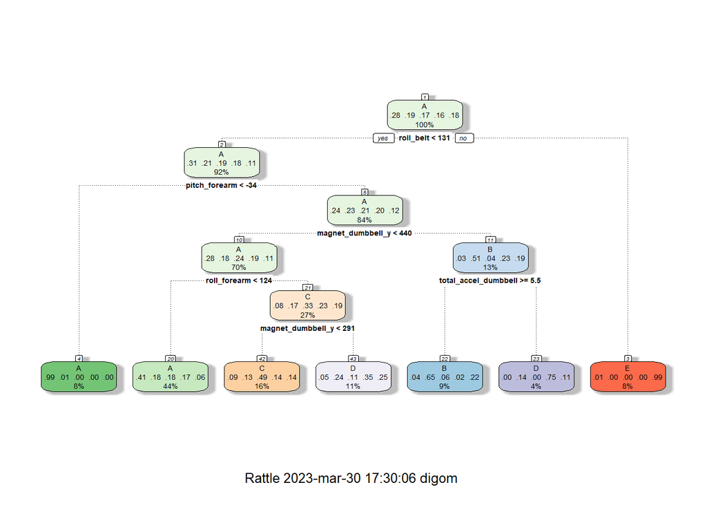

```r
control <- trainControl(method="cv", number=5, verboseIter=F)

trees_model <- train(classe ~ ., data=training, method="rpart", trControl = control, tuneLength = 5)
fancyRpartPlot(trees_model$finalModel)
```

```r
trees_pred <- predict(trees_model, validation)
trees_cm <- confusionMatrix(trees_pred, factor(validation$classe))
trees_cm
```

```
## Confusion Matrix and Statistics
##
##           Reference
## Prediction    A    B    C    D    E
##          A 1518  473  487  446  168
##          B   24  332   27   10  121
##          C   82  130  434  141  122
##          D   47  204   78  367  172
##          E    3    0    0    0  499
##
## Overall Statistics
##
##                Accuracy : 0.5353
##                  95% CI : (0.5224, 0.5481)
##     No Information Rate : 0.2845
##     P-Value [Acc > NIR] : < 2.2e-16
##
##                   Kappa : 0.394
##
##  Mcnemar's Test P-Value : < 2.2e-16
##
## Statistics by Class:
##
##                      Class: A Class: B Class: C Class: D Class: E
## Sensitivity            0.9068  0.29148  0.42300  0.38071  0.46118
## Specificity            0.6262  0.96165  0.90224  0.89819  0.99938
## Pos Pred Value         0.4909  0.64591  0.47745  0.42281  0.99402
## Neg Pred Value         0.9441  0.84975  0.88103  0.88100  0.89170
## Prevalence             0.2845  0.19354  0.17434  0.16381  0.18386
## Detection Rate         0.2579  0.05641  0.07375  0.06236  0.08479
## Detection Prevalence   0.5254  0.08734  0.15446  0.14749  0.08530
## Balanced Accuracy      0.7665  0.62657  0.66262  0.63945  0.73028
```

## Random Forest Model

```r
rf_model <- train(classe ~ ., data=training, method="rf", trControl = control, tuneLength = 5)

rf_pred <- predict(rf_model, validation)
rf_cm <- confusionMatrix(rf_pred, factor(validation$classe))
rf_cm
```

```
## Confusion Matrix and Statistics
##
##           Reference
## Prediction    A    B    C    D    E
##          A 1673    6    0    0    0
##          B    1 1131    5    0    1
##          C    0    1 1018   17    3
##          D    0    1    3  946    0
##          E    0    0    0    1 1078
##
## Overall Statistics
##
##                Accuracy : 0.9934
##                  95% CI : (0.991, 0.9953)
##     No Information Rate : 0.2845
##     P-Value [Acc > NIR] : < 2.2e-16
##
##                   Kappa : 0.9916
##
##  Mcnemar's Test P-Value : NA
##
## Statistics by Class:
##
##                      Class: A Class: B Class: C Class: D Class: E
## Sensitivity            0.9994   0.9930   0.9922   0.9813   0.9963
## Specificity            0.9986   0.9985   0.9957   0.9992   0.9998
## Pos Pred Value         0.9964   0.9938   0.9798   0.9958   0.9991
## Neg Pred Value         0.9998   0.9983   0.9983   0.9964   0.9992
## Prevalence             0.2845   0.1935   0.1743   0.1638   0.1839
## Detection Rate         0.2843   0.1922   0.1730   0.1607   0.1832
## Detection Prevalence   0.2853   0.1934   0.1766   0.1614   0.1833
## Balanced Accuracy      0.9990   0.9958   0.9939   0.9903   0.9980
```

## Gradient Boosted Trees Model

```r
gbm_model <- train(classe~., data=training, method="gbm", trControl = control, tuneLength = 5, verbose = F)

pred_gbm <- predict(gbm_model, validation)
gbm_cm <- confusionMatrix(pred_gbm, factor(validation$classe))
gbm_cm
```

```
## Confusion Matrix and Statistics
##
##           Reference
## Prediction    A    B    C    D    E
##          A 1668   13    0    0    0
##          B    2 1115   14    1    0
##          C    2   11 1006   23    5
##          D    1    0    6  939    2
##          E    1    0    0    1 1075
##
## Overall Statistics
##
##                Accuracy : 0.9861
##                  95% CI : (0.9827, 0.9889)
##     No Information Rate : 0.2845
##     P-Value [Acc > NIR] : < 2.2e-16
##
##                   Kappa : 0.9824
##
##  Mcnemar's Test P-Value : NA
##
## Statistics by Class:
##
##                      Class: A Class: B Class: C Class: D Class: E
## Sensitivity            0.9964   0.9789   0.9805   0.9741   0.9935
## Specificity            0.9969   0.9964   0.9916   0.9982   0.9996
## Pos Pred Value         0.9923   0.9850   0.9608   0.9905   0.9981
## Neg Pred Value         0.9986   0.9950   0.9959   0.9949   0.9985
## Prevalence             0.2845   0.1935   0.1743   0.1638   0.1839
## Detection Rate         0.2834   0.1895   0.1709   0.1596   0.1827
## Detection Prevalence   0.2856   0.1924   0.1779   0.1611   0.1830
## Balanced Accuracy      0.9967   0.9877   0.9860   0.9861   0.9966
```

## Predict on test set

From the results above it is possible to conclude that the Random Forest Approach was the best when it comes to accuracy. The Prediction of testing set cases is shown below

```r
testing <- testing[names(testing) %in% names(training)]
pred <- predict(rf_model, testing)
print(pred)
```

```
##  [1] B A B A A E D B A A B C B A E E A B B B
## Levels: A B C D E
```